# Overview

### Create cell-by-promoter matrix

Read 127 genomic regions of active promoter in epigenomic MERFISH

```python
h3k4me3_df = pd.read_table('./data/merfish_h3k4me3.bed',names=['chr','spos','epos','gene'])
```

```python
h3k4me3_df
```

|  | chr | spos | epos | gene |
| --- | --- | --- | --- | --- |
| 0 | chr1 | 4495897 | 4497608 | Sox17 |
| 1 | chr1 | 19102291 | 19111666 | Tfap2d |
| 2 | chr1 | 56967534 | 56974652 | Satb2 |
| 3 | chr1 | 69104151 | 69108917 | Erbb4 |
| 4 | chr1 | 75276812 | 75278734 | Resp18 |
| ... | ... | ... | ... | ... |
| 122 | chr9 | 118476285 | 118481523 | Eomes |
| 123 | chr9 | 123677841 | 123679258 | Slc6a20a |
| 124 | chr9 | 58195265 | 58205495 | Islr2 |
| 125 | chr9 | 85842394 | 85844555 | Tpbg |
| 126 | chr9 | 121493498 | 121496064 | Cck |

127 rows × 4 columns

```python
peak_list = [i+':'+str(j)+'-'+str(z) for i,j,z in zip(h3k4me3_df['chr'],h3k4me3_df['spos'],h3k4me3_df['epos'])]
```

```python
peak_list
```

```
['chr1:4495897-4497608',
 'chr1:19102291-19111666',
 'chr1:56967534-56974652',
 'chr1:69104151-69108917',
 'chr1:75276812-75278734',
 'chr1:89927107-89933098',
 'chr1:90153243-90153881',
 'chr1:120598027-120608358',
 'chr1:167618233-167618813',
 'chr1:191097509-191098946',
 'chr1:5588150-5589330',
 'chr10:127533706-127535173',
 'chr11:44616408-44622775',
 'chr11:69045142-69047132',
 'chr11:78301119-78302685',
 'chr11:84518344-84528868',
 'chr11:95512620-95515317',
 'chr11:99022745-99025000',
 'chr11:106713884-106714574',
 'chr11:113618571-113621380',
 'chr11:117824893-117826637',
 'chr12:49375314-49387183',
 'chr12:107996691-108006757',
 'chr12:9570012-9570976',
 'chr12:116077222-116078366',
 'chr13:8202156-8208114',
 'chr13:16011456-16012897',
 'chr13:78189469-78205118',
 'chr13:116308038-116310995',
 'chr14:8316489-8318081',
 'chr14:12340159-12347540',
 'chr14:48660939-48672573',
 'chr14:70888271-70895383',
 'chr14:32462602-32465570',
 'chr15:8707624-8711296',
 'chr15:79161497-79164515',
 'chr15:55111915-55113730',
 'chr15:97766104-97768745',
 'chr16:23889304-23891224',
 'chr16:45093814-45094701',
```

[output cut: 72 more lines]

```
 'chr8:23410751-23414793',
 'chr8:29215777-29220242',
 'chr8:68880125-68882387',
 'chr8:71396264-71397794',
 'chr8:110167267-110168687',
 'chr8:125994671-125998574',
 'chr8:55939958-55941106',
 'chr9:37551274-37553264',
 'chr9:57501313-57505162',
 'chr9:87729176-87731648',
 'chr9:118476285-118481523',
 'chr9:123677841-123679258',
 'chr9:58195265-58205495',
 'chr9:85842394-85844555',
 'chr9:121493498-121496064']
```

Create cell-by-promoter count matrix

```python
adata_h3k4me3_merfish = snap.pp.make_peak_matrix(adata_h3k4me3,use_rep=peak_list, file="paired-tag_h3k4me3.merfish_peak.h5ad")
```

```python
# Assign lost cell ids
adata_h3k4me3_merfish.obs_names = adata_h3k4me3.obs_names
# Assign gene names
adata_h3k4me3_merfish.var['peaks'] = adata_h3k4me3_merfish.var_names
adata_h3k4me3_merfish.var_names = h3k4me3_df['gene']
# Assign lost spatial cooridinate
adata_h3k4me3_merfish.obsm['spatial'] = adata_h3k4me3.obsm['spatial']
```

```python
adata_h3k4me3_merfish
```

```
AnnData object with n_obs x n_vars = 2384 x 127 backed at 'paired-tag_h3k4me3.merfish_peak.h5ad'
    obs: 'tsse', 'n_fragment', 'frac_dup', 'frac_mito', 'doublet_score', 'is_doublet', 'x_noise', 'y_noise', 'cell_type'
    var: 'peaks'
    obsm: 'spatial'
```

Save and re-read using scanpy for better manipulation

```python
adata_h3k4me3_merfish.write('./paired-tag_h3k4me3.merfish_peak.scanpy.h5ad')
adata_h3k4me3_merfish = sc.read_h5ad('paired-tag_h3k4me3.merfish_peak.scanpy.h5ad')
```

```python
adata_h3k4me3_merfish
```

```
AnnData object with n_obs × n_vars = 2384 × 127
    obs: 'tsse', 'n_fragment', 'frac_dup', 'frac_mito', 'doublet_score', 'is_doublet', 'x_noise', 'y_noise', 'cell_type'
    var: 'peaks'
    obsm: 'spatial'
```

Perform normalization

```python
# Normalize
sc.pp.normalize_total(adata_h3k4me3_merfish)
sc.pp.log1p(adata_h3k4me3_merfish)
```

```python
adata_h3k4me3_merfish
```

```
AnnData object with n_obs × n_vars = 2384 × 127
    obs: 'tsse', 'n_fragment', 'frac_dup', 'frac_mito', 'doublet_score', 'is_doublet', 'x_noise', 'y_noise', 'cell_type'
    var: 'peaks'
    uns: 'log1p'
    obsm: 'spatial'
```

### Comparison between H3K4me3 signals and spatial patterns of their corresponding gene expression

Here we compare the spatial distribution of H3K4me3 signals in active promoters with spatial patterns of their corresponding gene expression. We found that although the H3K4me3 signals are sparse, their layer enrichment patterns are largely similar with that in scRNA-seq.

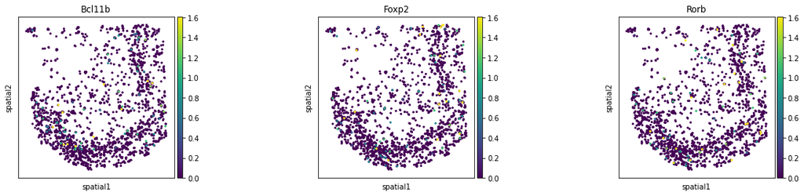

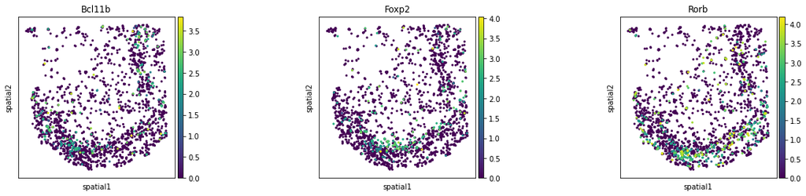

```python
# Bcl11b promoter - h3k4me3 signal
sc.pl.spatial(adata_h3k4me3_merfish,color=['Bcl11b','Foxp2','Rorb'],spot_size=50,ncols=3)
# Bcl11b - single-cell gene expression
sc.pl.spatial(adata_sc,color=['Bcl11b','Foxp2','Rorb'],spot_size=50,ncols=3)
```

# Compare the spatial pattern of H3K4me3 with epigenomic MERFISH

We compared the spatial map of H3K4me3 signals constructed using STellaris with epigenomic MERFISH, which directly profiles H3K4me3 pattern in situ.

Here we focused on cortical region and found that layer enrichment measured by our results are largely consistent with epigenomic MERFISH, which demonstrated the feasibility of STellaris in single-cell multiomics data to charaterize gene regulatory mechanisim at a spatial context.

### Extract cerebral cortex region

First, extract cortex using polynomial regression

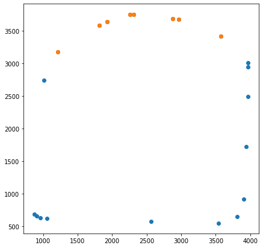

```python
spots = adata_h3k4me3_merfish.obsm['spatial']
hull = ConvexHull(spots)
hull_x = spots[hull.vertices,0]
hull_y = spots[hull.vertices,1]
hull_x_cortex = spots[list(hull.vertices[13:]),0]
hull_y_cortex = spots[list(hull.vertices[13:]),1]
fig, ax = plt.subplots(figsize=(7,7))
ax.scatter(hull_x, hull_y)
ax.scatter(hull_x_cortex, hull_y_cortex)
fig.show()
```

```python
# fit polynomial
z = np.polyfit(hull_x_cortex, hull_y_cortex, 2)
p1 = np.poly1d(z)
```

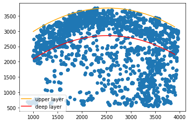

```python
# visualization
plt.plot(spots[:,0], spots[:,1], 'o')
p2 = p1-900
y_pred1 = p1(list(range(1000,4000,100)))
y_pred2 = p2(list(range(1000,4000,100)))
plot1 = plt.plot(list(range(1000,4000,100)), y_pred1, label='upper layer',color='orange')
plot2 = plt.plot(list(range(1000,4000,100)), y_pred2, label='deep layer',color='red')
plt.title('')
plt.xlabel('')
plt.ylabel('')
plt.legend(loc=3,borderaxespad=0,bbox_to_anchor=(0,0))
plt.show()
```

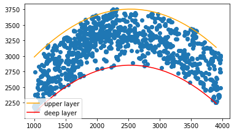

```python
# Extract cells belonging to cortex
x_all = spots[:,0]
y_all = spots[:,1]
cells_all = adata_h3k4me3_merfish.obs_names
x_keep = []
y_keep = []
cells_keep = []
for i,j,z in zip(x_all,y_all,cells_all):
    if p2(i)<j:
        x_keep.append(i)
        y_keep.append(j)
        cells_keep.append(z)
    else:
        continue
plt.plot(x_keep, y_keep, 'o')
plot1 = plt.plot(list(range(1000,4000,100)), y_pred1, label='upper layer',color='orange')
plot2 = plt.plot(list(range(1000,4000,100)), y_pred2, label='deep layer',color='red')
plt.title('')
plt.xlabel('')
plt.ylabel('')
plt.legend(loc=3,borderaxespad=0,bbox_to_anchor=(0,0))
plt.axis('scaled')
plt.show()
```

```python
adata_h3k4me3_merfish = adata_h3k4me3_merfish[adata_h3k4me3_merfish.obs_names.isin(cells_keep)].copy()
```

```python
adata_sc = adata_sc[adata_sc.obs_names.isin(cells_keep)].copy()
```

### Distribution of H3K4me3 signals along radial axis of cortex

Here we will assess the spatial distributions of layer-enriched active promoters interrogated in epigenomic MERFISH paper.

For each layer-specific promoters in MERFISH, We summarise the spatial distribution of H3K4me3 histone modification as the minimum distance of H3K4me3 centroid to the surface of cortex. It is expected that upper layer H3K4me3 loci have lower distance values.

The layer distriubiton of 38 H3K4me3 loci from epigenomic MERFISH paper (https://doi.org/10.1016/j.cell.2022.09.035) is shown below:

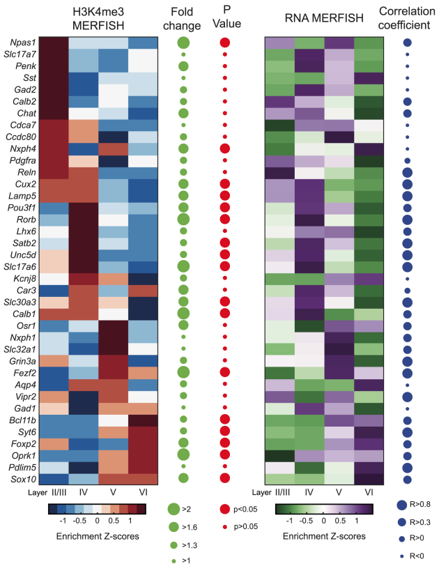

```python
def max_min_norm(gene_exp):
    max_l = max(gene_exp)
    min_l = min(gene_exp)
    gene_exp_norm = [((i-min_l)/(max_l-min_l))*2 for i in gene_exp]
    return gene_exp_norm
```

```python
## Find centroid
def get_centroid(adata, gene_name, x_keep, y_keep, if_plot=True, if_norm=True):
    if if_norm:
        adata_norm = adata.copy()
        sc.pp.normalize_total(adata_norm)
        sc.pp.log1p(adata_norm)
    else:
        adata_norm = adata.copy()
    gene_exp = adata_norm[:,gene_name].X.toarray()[:,0]
    #gene_exp = max_min_norm(gene_exp)
    x_tmp = []
    for n in range(len(x_keep)):
        x_tmp.append(x_keep[n]*gene_exp[n])
    x_mean = np.sum(x_tmp)/np.sum(gene_exp)
    y_tmp = []
    for n in range(len(y_keep)):
        y_tmp.append(y_keep[n]*gene_exp[n])
    y_mean = np.sum(y_tmp)/np.sum(gene_exp)
    if if_plot:
        sc.pl.spatial(adata_norm,color=gene_name,spot_size=50)
        plt.plot(x_keep, y_keep, 'o')
        plt.scatter(x_mean,y_mean,c='r')
        pylab.title('')
        pylab.xlabel('')
        pylab.ylabel('')
        pylab.legend(loc=3, borderaxespad=0., bbox_to_anchor=(0, 0))
        pylab.show()
    else:
        pass
    return [x_mean,y_mean]
```

```python
## Calculate the distance of centroid to the surface of cortex
def get_dis(curve, point):
    xList = np.linspace(1000,4000,300001)
    xList = xList.tolist()
    yList = []
    for xp in xList:
        yp = curve(xp)
        yList.append(yp)
    dis_list = []
    for n in range(len(xList)):
        dis = np.sqrt((np.square(point[0]-xList[n])+np.square(point[1]-yList[n])))
        dis_list.append(dis)
    dis_min = np.min(dis_list)
    return dis_min
```

```python
marker_genes = ['Npas1','Slc17a7','Penk','Sst','Gad2','Calb2','Chat','Cdca7','Ccdc80','Nxph4'
                ,'Pdgfra','Reln','Cux2','Lamp5','Pou3f1','Rorb','Lhx6','Satb2','Unc5d'
                ,'Slc17a6','Kcnj8','Car3','Slc30a3','Calb1','Osr1','Nxph1','Slc32a1','Grin3a',
               'Fezf2','Aqp4','Vipr2','Gad1','Bcl11b','Syt6','Foxp2','Oprk1','Pdlim5','Sox10']
dis_dic = {}
for gene in marker_genes:
    try:
        centroid = get_centroid(adata_h3k4me3_merfish, gene_name=gene,x_keep=x_keep,y_keep=y_keep,if_plot=False)
    except:
        print('no '+gene)
        continue
    dis_dic[gene] = get_dis(curve=p1, point=centroid)
    #print(gene+': '+str(dis_dic[gene]))
```

[output not shown]

[output not shown]

```python
dis_dic
```

```
{'Npas1': 371.8435139249171,
 'Slc17a7': 667.9104329325937,
 'Penk': 411.87730582356,
 'Sst': 256.8483202012105,
 'Gad2': 546.0870590195717,
 'Calb2': 528.7913315333836,
 'Chat': 522.9278973139577,
 'Cdca7': 635.2219396220006,
 'Ccdc80': 503.72132645051744,
 'Nxph4': 913.8402138700891,
 'Pdgfra': 599.334737913344,
 'Reln': 348.71522617729323,
 'Cux2': 661.1860032685722,
 'Lamp5': 519.0653454009516,
 'Pou3f1': 715.229553311471,
 'Rorb': 570.5470677911715,
 'Lhx6': 868.7526493497869,
 'Satb2': 607.9970337486903,
 'Unc5d': 680.9989603268904,
 'Slc17a6': 516.5900799227072,
 'Kcnj8': 511.97815173834346,
 'Car3': 725.7574331403436,
 'Slc30a3': 736.3711565993717,
 'Calb1': 588.0016232923651,
 'Osr1': nan,
 'Nxph1': 645.7842619003641,
 'Slc32a1': 758.5585603834803,
 'Grin3a': 545.1713377396766,
 'Fezf2': 737.2688171958309,
 'Aqp4': 164.9103750451899,
 'Vipr2': 576.7185121047354,
 'Gad1': 648.3913679077232,
 'Bcl11b': 760.3996978142582,
 'Syt6': 365.647553189487,
 'Foxp2': 715.6397293002423,
 'Oprk1': nan,
 'Pdlim5': 681.0005210575167,
 'Sox10': 453.4394148907722}
```

```python
# Candidate layer-enriched H3K4me3 loci according to epigenomic MERFISH paper
cortex23 = []
cortex23_list = ['Gad2','Calb2','Chat']
for g in cortex23_list:
    cortex23.append(dis_dic[g])
cortex4 = []
cortex4_list = ['Pou3f1','Rorb','Lhx6','Satb2','Unc5d'
                ,'Slc17a6','Kcnj8','Car3','Slc30a3']
for g in cortex4_list:
    cortex4.append(dis_dic[g])
cortex56 = []
cortex56_list = ['Nxph1','Slc32a1',
               'Fezf2','Bcl11b','Syt6','Foxp2','Pdlim5','Sox10']
for g in cortex56_list:
    cortex56.append(dis_dic[g])
```

Now plot the distribution of the distance of centroid to cortex surface, the layer enrichment pattern reported in epigenomic MERFISH is also manifested in the spatial mapping approach.

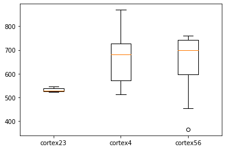

```python
plt.boxplot((cortex23,cortex4,cortex56),labels=('cortex23','cortex4','cortex56'))
plt.show()
```

# Modules and their versions used for this analysis

```python
import sys
for module in sys.modules:
    try:
        print(module,sys.modules[module].__version__)
    except:
        try:
            if  type(modules[module].version) is str:
                print(module,sys.modules[module].version)
            else:
                print(module,sys.modules[module].version())
        except:
            try:
                print(module,sys.modules[module].VERSION)
            except:
                pass
```

```
re 2.2.1
ipykernel._version 6.9.1
json 2.0.9
jupyter_client._version 7.2.2
traitlets._version 5.1.1
traitlets 5.1.1
logging 0.5.1.2
platform 1.0.8
_ctypes 1.1.0
ctypes 1.1.0
zmq.sugar.version 23.2.0
zmq.sugar 23.2.0
zmq 23.2.0
argparse 1.1
zlib 1.0
_curses b'2.2'
dateutil 2.8.2
six 1.16.0
_decimal 1.70
decimal 1.70
jupyter_core.version 4.10.0
jupyter_core 4.10.0
entrypoints 0.4
jupyter_client 7.2.2
ipykernel 6.9.1
IPython.core.release 8.4.0
executing.version 0.8.3
executing 0.8.3
pure_eval.version 0.2.2
pure_eval 0.2.2
stack_data.version 0.2.0
stack_data 0.2.0
pygments 2.11.2
ptyprocess 0.7.0
pexpect 4.8.0
pickleshare 0.7.5
backcall 0.2.0
decorator 5.1.1
wcwidth 0.2.5
prompt_toolkit 3.0.20
```

[output cut: 133 more lines]

```
socks 1.7.1
requests 2.28.1
appdirs 1.4.4
tqdm._dist_ver 4.64.1
tqdm.version 4.64.1
tqdm.cli 4.64.1
tqdm 4.64.1
pooch v1.6.0
rustworkx.rustworkx 0.12.1
rustworkx 0.12.1
snapatac2 2.2.0
polars 0.15.5
kaleido._version 0.2.1
kaleido 0.2.1
plotly.version 5.11.0
```